# week1

```python
import numpy as np
import pandas as pd
```

## 1. 데이터 전처리

### 1.1 데이터 불러오기

```python
data = pd.read_csv("data.csv")
```

### 1.2 데이터 확인

```python
# row와 column 개수 확인
data.shape
```

```
(1216553, 13)
```

```python
# head
data.head(10)
```

|  | transaction_id | apartment_id | city | dong | jibun | apt | addr_kr | exclusive_use_area | year_of_completion | transaction_year_month | transaction_date | floor | transaction_real_price |
| --- | --- | --- | --- | --- | --- | --- | --- | --- | --- | --- | --- | --- | --- |
| 0 | 0 | 7622 | 서울특별시 | 신교동 | 6-13 | 신현(101동) | 신교동 6-13 신현(101동) | 84.82 | 2002 | 200801 | 21~31 | 2 | 37500 |
| 1 | 1 | 5399 | 서울특별시 | 필운동 | 142 | 사직파크맨션 | 필운동 142 사직파크맨션 | 99.17 | 1973 | 200801 | 1~10 | 6 | 20000 |
| 2 | 2 | 3578 | 서울특별시 | 필운동 | 174-1 | 두레엘리시안 | 필운동 174-1 두레엘리시안 | 84.74 | 2007 | 200801 | 1~10 | 6 | 38500 |
| 3 | 3 | 10957 | 서울특별시 | 내수동 | 95 | 파크팰리스 | 내수동 95 파크팰리스 | 146.39 | 2003 | 200801 | 11~20 | 15 | 118000 |
| 4 | 4 | 10639 | 서울특별시 | 내수동 | 110-15 | 킹스매너 | 내수동 110-15 킹스매너 | 194.43 | 2004 | 200801 | 21~31 | 3 | 120000 |
| 5 | 5 | 12536 | 서울특별시 | 인의동 | 48-2 | 효성쥬얼리시티 | 인의동 48-2 효성쥬얼리시티 | 106.81 | 2006 | 200801 | 1~10 | 16 | 67000 |
| 6 | 6 | 12536 | 서울특별시 | 인의동 | 48-2 | 효성쥬얼리시티 | 인의동 48-2 효성쥬얼리시티 | 92.81 | 2006 | 200801 | 1~10 | 7 | 50270 |
| 7 | 7 | 12536 | 서울특별시 | 인의동 | 48-2 | 효성쥬얼리시티 | 인의동 48-2 효성쥬얼리시티 | 98.39 | 2006 | 200801 | 11~20 | 7 | 46000 |
| 8 | 8 | 12536 | 서울특별시 | 인의동 | 48-2 | 효성쥬얼리시티 | 인의동 48-2 효성쥬얼리시티 | 84.64 | 2006 | 200801 | 21~31 | 15 | 35368 |
| 9 | 9 | 12536 | 서울특별시 | 인의동 | 48-2 | 효성쥬얼리시티 | 인의동 48-2 효성쥬얼리시티 | 84.98 | 2006 | 200801 | 21~31 | 7 | 46800 |

```python
#info
data.info()
```

```
<class 'pandas.core.frame.DataFrame'>
RangeIndex: 1216553 entries, 0 to 1216552
Data columns (total 13 columns):
 #   Column                  Non-Null Count    Dtype
---  ------                  --------------    -----
 0   transaction_id          1216553 non-null  int64
 1   apartment_id            1216553 non-null  int64
 2   city                    1216553 non-null  object
 3   dong                    1216553 non-null  object
 4   jibun                   1216553 non-null  object
 5   apt                     1216553 non-null  object
 6   addr_kr                 1216553 non-null  object
 7   exclusive_use_area      1216553 non-null  float64
 8   year_of_completion      1216553 non-null  int64
 9   transaction_year_month  1216553 non-null  int64
 10  transaction_date        1216553 non-null  object
 11  floor                   1216553 non-null  int64
 12  transaction_real_price  1216553 non-null  int64
dtypes: float64(1), int64(6), object(6)
memory usage: 120.7+ MB
```

```python
pd.isnull(data)
```

|  | transaction_id | apartment_id | city | dong | jibun | apt | addr_kr | exclusive_use_area | year_of_completion | transaction_year_month | transaction_date | floor | transaction_real_price |
| --- | --- | --- | --- | --- | --- | --- | --- | --- | --- | --- | --- | --- | --- |
| 0 | False | False | False | False | False | False | False | False | False | False | False | False | False |
| 1 | False | False | False | False | False | False | False | False | False | False | False | False | False |
| 2 | False | False | False | False | False | False | False | False | False | False | False | False | False |
| 3 | False | False | False | False | False | False | False | False | False | False | False | False | False |
| 4 | False | False | False | False | False | False | False | False | False | False | False | False | False |
| ... | ... | ... | ... | ... | ... | ... | ... | ... | ... | ... | ... | ... | ... |
| 1216548 | False | False | False | False | False | False | False | False | False | False | False | False | False |
| 1216549 | False | False | False | False | False | False | False | False | False | False | False | False | False |
| 1216550 | False | False | False | False | False | False | False | False | False | False | False | False | False |
| 1216551 | False | False | False | False | False | False | False | False | False | False | False | False | False |
| 1216552 | False | False | False | False | False | False | False | False | False | False | False | False | False |

1216553 rows × 13 columns

### 1.3 불필요한 행 삭제

```python
data =  data[data.city == '서울특별시']
```

```python
data.reset_index(inplace = True)
```

### 1.4 변수 이름 바꾸기

```python
data.rename(columns = {'transaction_real_price' : 'price'}, inplace = True)
```

### 1.5 불필요한 변수 삭제

```python
data.drop(columns = {'transaction_id', 'apartment_id', 'jibun', 'city'}, axis = 1, inplace = True)
```

```python
data.shape
```

```
(742285, 10)
```

### 1.6 연/월 뽑기

```python
data['transaction_year'] = 0
data['transaction_year'] = data['transaction_year_month'] // 100
```

```python
data['transaction_month'] = 0
data['transaction_month'] = data['transaction_year_month'] % 100
```

```python
data.head(10)
```

|  | index | dong | apt | addr_kr | exclusive_use_area | year_of_completion | transaction_year_month | transaction_date | floor | price | transaction_year | transaction_month |
| --- | --- | --- | --- | --- | --- | --- | --- | --- | --- | --- | --- | --- |
| 0 | 0 | 신교동 | 신현(101동) | 신교동 6-13 신현(101동) | 84.82 | 2002 | 200801 | 21~31 | 2 | 37500 | 2008 | 1 |
| 1 | 1 | 필운동 | 사직파크맨션 | 필운동 142 사직파크맨션 | 99.17 | 1973 | 200801 | 1~10 | 6 | 20000 | 2008 | 1 |
| 2 | 2 | 필운동 | 두레엘리시안 | 필운동 174-1 두레엘리시안 | 84.74 | 2007 | 200801 | 1~10 | 6 | 38500 | 2008 | 1 |
| 3 | 3 | 내수동 | 파크팰리스 | 내수동 95 파크팰리스 | 146.39 | 2003 | 200801 | 11~20 | 15 | 118000 | 2008 | 1 |
| 4 | 4 | 내수동 | 킹스매너 | 내수동 110-15 킹스매너 | 194.43 | 2004 | 200801 | 21~31 | 3 | 120000 | 2008 | 1 |
| 5 | 5 | 인의동 | 효성쥬얼리시티 | 인의동 48-2 효성쥬얼리시티 | 106.81 | 2006 | 200801 | 1~10 | 16 | 67000 | 2008 | 1 |
| 6 | 6 | 인의동 | 효성쥬얼리시티 | 인의동 48-2 효성쥬얼리시티 | 92.81 | 2006 | 200801 | 1~10 | 7 | 50270 | 2008 | 1 |
| 7 | 7 | 인의동 | 효성쥬얼리시티 | 인의동 48-2 효성쥬얼리시티 | 98.39 | 2006 | 200801 | 11~20 | 7 | 46000 | 2008 | 1 |
| 8 | 8 | 인의동 | 효성쥬얼리시티 | 인의동 48-2 효성쥬얼리시티 | 84.64 | 2006 | 200801 | 21~31 | 15 | 35368 | 2008 | 1 |
| 9 | 9 | 인의동 | 효성쥬얼리시티 | 인의동 48-2 효성쥬얼리시티 | 84.98 | 2006 | 200801 | 21~31 | 7 | 46800 | 2008 | 1 |

### 1.7 필요 연도 뽑기

```python
data = data[data['transaction_year'] >= 2012]
```

```python
data.reset_index(inplace = True)
```

## 2. 데이터 시각화

### 2.1 거래가격 분포 확인

```python
import matplotlib.pyplot as plt
import seaborn as sns
```

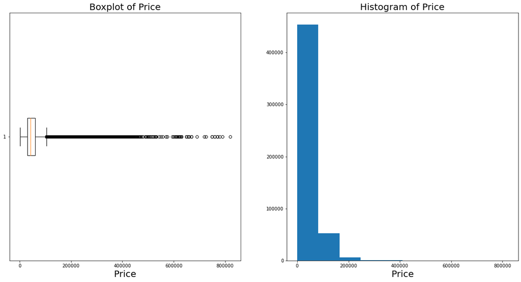

```python
firstplot = plt.figure(figsize = (20, 10))
axes1 = firstplot.add_subplot(1, 2, 1)
axes2 = firstplot.add_subplot(1, 2, 2)

axes1.boxplot(data['price'], vert = False)
axes1.set_title('Boxplot of Price', fontsize = 20)
axes1.set_xlabel('Price', fontsize = 20)

axes2.hist(data['price'])
axes2.set_title('Histogram of Price', fontsize = 20)
axes2.set_xlabel('Price', fontsize = 20)
```

거래가격은 보통 0~150000 정도에 분포되어 있는 것으로 보입니다.

### 2.2 거래연도 분포 확인 / 거래연도별 가격 분포 확인

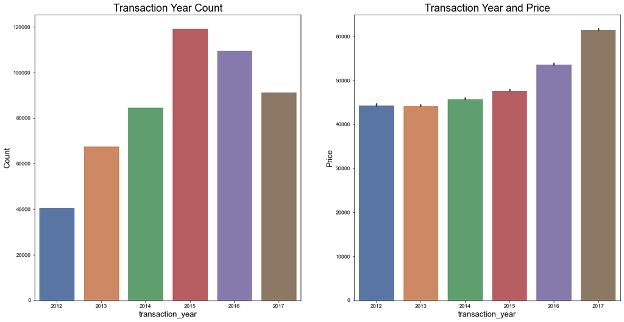

```python
secondplot, axes = plt.subplots(1, 2, figsize = (20, 10))
sns.set_theme(style = 'darkgrid')
sns.countplot(ax = axes[0], x = 'transaction_year', data = data)
sns.barplot(ax = axes[1], x = 'transaction_year', y = 'price', data = data)

axes[0].set_title('Transaction Year Count', fontsize = 20)
axes[1].set_title('Transaction Year and Price', fontsize = 20)

axes[0].set_xlabel('transaction_year', size = 15)
axes[1].set_xlabel('transaction_year', size = 15)

axes[0].set_ylabel('Count', size = 15)
axes[1].set_ylabel('Price', size = 15)
```

### 2.3 층 분포 확인 / 층별 가격 분포 확인

```
[]
```

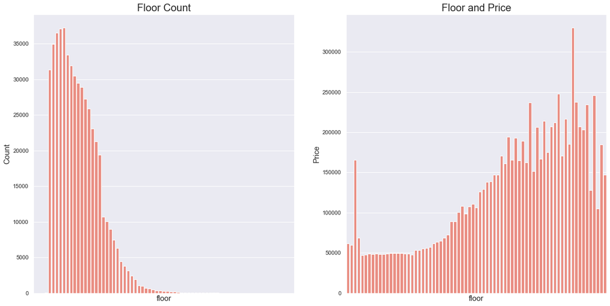

```python
thirdplot, axes = plt.subplots(1, 2, figsize = (20, 10))
sns.set_theme(style = 'darkgrid')
sns.countplot(ax = axes[0], x = 'floor', data = data, color = 'salmon')
sns.barplot(ax = axes[1], x = 'floor', y = 'price', data = data,  color = 'salmon', ci = None)

axes[0].set_title('Floor Count', fontsize = 20)
axes[1].set_title('Floor and Price', fontsize = 20)

axes[0].set_xlabel('floor', size = 15)
axes[1].set_xlabel('floor', size = 15)

axes[0].set_ylabel('Count', size = 15)
axes[1].set_ylabel('Price', size = 15)

axes[0].set_xticks([])
axes[1].set_xticks([])
```

비교적 낮은 층일수록 거래 빈도가 높은 것을 확인할 수 있습니다. 또한, 고층일수록 가격은 상승하는 경향을 보이는데, 초고층의 경우 가격이 조금 하락하는 것을 확인할 수 있습니다.

### 2.4 완공연도 분포 확인 / 완공연도별 가격 분포 확인

```
[]
```

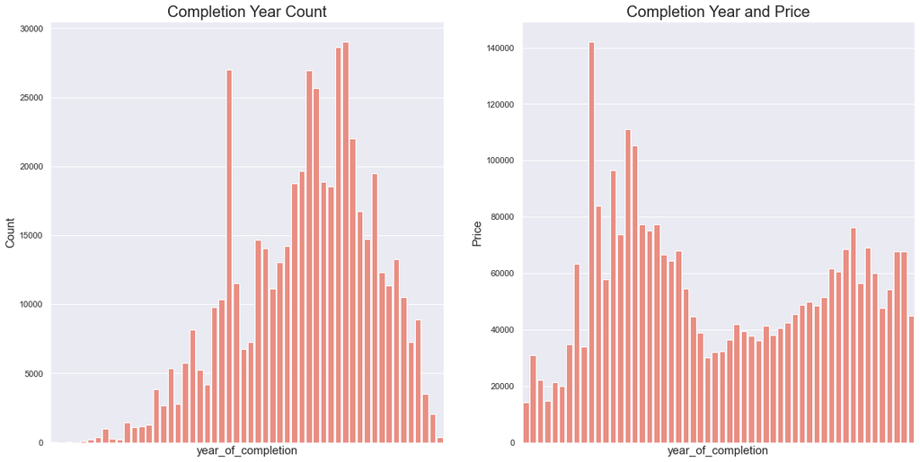

```python
fourthplot, axes = plt.subplots(1, 2, figsize = (20, 10))
sns.set_theme(style = 'darkgrid')
sns.countplot(ax = axes[0], x = 'year_of_completion', data = data, color = 'salmon')
sns.barplot(ax = axes[1], x = 'year_of_completion', y = 'price', data = data,  color = 'salmon', ci = None)

axes[0].set_title('Completion Year Count', fontsize = 20)
axes[1].set_title('Completion Year and Price', fontsize = 20)

axes[0].set_xlabel('year_of_completion', size = 15)
axes[1].set_xlabel('year_of_completion', size = 15)

axes[0].set_ylabel('Count', size = 15)
axes[1].set_ylabel('Price', size = 15)

axes[0].set_xticks([])
axes[1].set_xticks([])
```

완공연도가 최근에 가까워질수록 거래 횟수가 증가하다가, 일정 시점에서부터는 거래 횟수가 감소하는 것을 확인할 수 있습니다. 완공 연도가 최근인 아파트보다는 오래된 아파트들의 평균거래가격이 더 높은 것을 확인할 수 있습니다.

## 3. 파생변수 생성

### 3.1 아파트 연차 변수 생성

```python
data['until_trans'] = data['transaction_year']  - data['year_of_completion']
```

```
[]
```

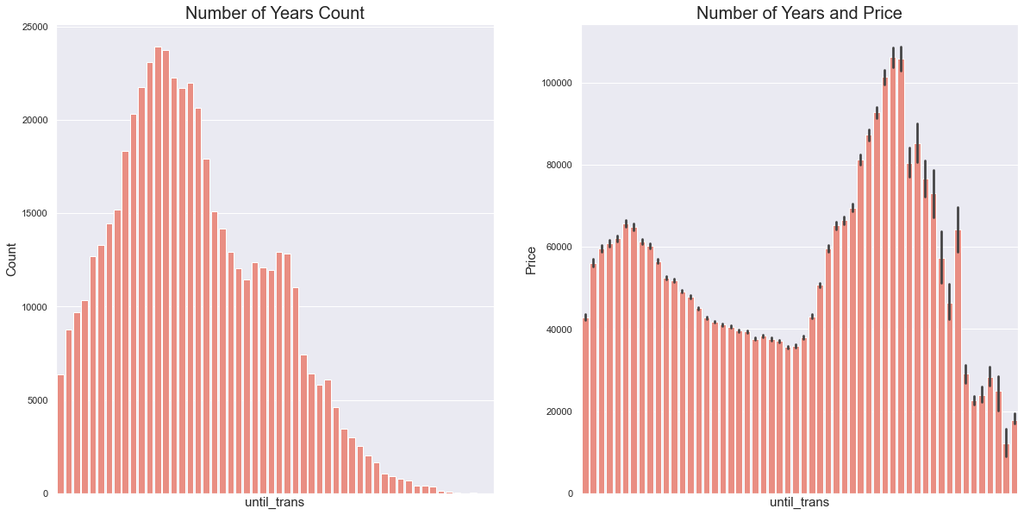

```python
fifthplot, axes = plt.subplots(1, 2, figsize = (20, 10))
sns.set_theme(style = 'darkgrid')
sns.countplot(ax = axes[0], x = 'until_trans', data = data, color = 'salmon')
sns.barplot(ax = axes[1], x = 'until_trans', y = 'price', data = data,  color = 'salmon')

axes[0].set_title('Number of Years Count', fontsize = 20)
axes[1].set_title('Number of Years and Price', fontsize = 20)

axes[0].set_xlabel('until_trans', size = 15)
axes[1].set_xlabel('until_trans', size = 15)

axes[0].set_ylabel('Count', size = 15)
axes[1].set_ylabel('Price', size = 15)

axes[0].set_xticks([])
axes[1].set_xticks([])
```

### 3.2 거래 일 변수 변환

```python
data['transaction_date'] = np.where(data['transaction_date'] == '1~10', 0,
                                   np.where(data['transaction_date'] == '11~20', 1, 2))
```

### 3.3 월 변수와 10일 단위 변수 통합

```python
data['transaction_month_date'] = 3 * data['transaction_month'] + data['transaction_date']
```

### 3.4 연도별 주기성을 위한 파생변수 생성 (삼각변환)

```python
import math
```

```python
data['sin_date'] = np.sin(2*np.pi*data.transaction_month_date/4)
data['cos_date'] = np.cos(2*np.pi*data.transaction_month_date/4)
```

```python
data.drop(columns = {'year_of_completion', 'transaction_year_month', 'transaction_date', 'transaction_month', 'transaction_month_date'},
          axis = 1, inplace = True)
```

### 3.5 삼각변환을 통한 장점

위와 같은 삼각변환을 했을 경우 시간과 같이 주기성을 갖는 변수의 연속적인 특성을 반영할 수 있다는 장점이 있다.

## 4. 텍스트 데이터 다루기

### 4.1 아파트 이름 한글부분만 뽑기

```python
apt= data['apt']
```

```python
result = pd.DataFrame(index = range(0,len(apt)), columns = ['apt'])
result['apt'] = 0
```

```python
import re
```

```python
for i in range(0,len(apt)):
    korean = re.compile('[^ㄱ-ㅣ가-힣]+')
    value = korean.sub('', apt[i])
    result[i:i+1] = value
```

```python
apt = result
apt.head(10)
```

|  | apt |
| --- | --- |
| 0 | 광화문풍림스페이스본 |
| 1 | 광화문풍림스페이스본 |
| 2 | 광화문풍림스페이스본 |
| 3 | 로얄팰리스스위트 |
| 4 | 로얄팰리스스위트 |
| 5 | 로얄팰리스스위트 |
| 6 | 로얄팰리스스위트 |
| 7 | 현대뜨레비앙 |
| 8 | 현대뜨레비앙 |
| 9 | 현대뜨레비앙 |

### 4.2 아파트 이름 DTM

```python
from sklearn.feature_extraction.text import CountVectorizer
```

```python
vec_count = CountVectorizer(min_df = 5)
apt_dtm = vec_count.fit_transform(apt['apt']).toarray()
```

```python
vec_count.vocabulary_
```

```
{'광화문풍림스페이스본': 270,
 '로얄팰리스스위트': 1037,
 '현대뜨레비앙': 3768,
 '운현신화타워': 2719,
 '창신쌍용': 3168,
 '동대문': 764,
 '두산': 886,
 '종로청계힐스테이트': 3048,
 '동일상가': 856,
 '렉스팰리스': 1023,
 '삼성': 1618,
 '대아파크빌': 622,
 '세종로대우': 2029,
 '파크팰리스': 3443,
 '킹스매너': 3343,
 '경희궁의아침단지': 184,
 '동성아파트동': 803,
 '아남': 2357,
 '동아': 814,
 '롯데캐슬로잔': 1057,
 '크래스빌': 3338,
 '롯데낙천대': 1049,
 '인왕산아이파크': 2895,
 '현대': 3754,
 '미도파': 1280,
 '효성쥬얼리시티': 3923,
 '종로센트레빌': 3044,
 '대성맨션': 607,
 '청운현대': 3272,
 '타워': 3345,
 '렉스빌': 1022,
 '창신이수': 3169,
 '브라운스톤창신': 1545,
 '벽산블루밍평창힐스': 1450,
 '갑을': 28,
 '그린동': 314,
 '르트랑시망': 1086,
 '무악다온채': 1245,
 '세종': 2026,
 '대성스카이렉스': 608,
```

[output cut: 946 more lines]

```
 '현대맨션': 3773,
 '썬힐하우스': 2341,
 '형인휴아름': 3851,
 '성덕': 1947,
 '북한산굿모닝': 1512,
 '은석': 2812,
 '이너스내안에': 2844,
 '두원프라자': 903,
 '대림수유': 564,
 '신일': 2281,
 '진안골드밸리': 3136,
 '골드빌': 206,
 '수유역하이씨티': 2094,
 '궁전': 301,
 ...}
```

### 4.3 아파트 이름 tf-idf

```python
from sklearn.feature_extraction.text import TfidfVectorizer
```

```python
vec_tfidf = TfidfVectorizer()
apt_tfidf = vec_tfidf.fit_transform(apt['apt']).toarray()
```

```python
vec_tfidf.vocabulary_
```

```
{'광화문풍림스페이스본': 323,
 '로얄팰리스스위트': 1315,
 '현대뜨레비앙': 4795,
 '운현신화타워': 3451,
 '창신쌍용': 4013,
 '동대문': 977,
 '두산': 1136,
 '종로청계힐스테이트': 3865,
 '동일상가': 1098,
 '렉스팰리스': 1295,
 '삼성': 2054,
 '프라임캐슬케이빌라트': 4478,
 '대아파크빌': 796,
 '세종로대우': 2573,
 '파크팰리스': 4383,
 '킹스매너': 4247,
 '경희궁의아침단지': 214,
 '동성아파트동': 1033,
 '아남': 2983,
 '동아': 1046,
 '롯데캐슬로잔': 1341,
 '크래스빌': 4241,
 '롯데낙천대': 1331,
 '인왕산아이파크': 3676,
 '현대': 4781,
 '미도파': 1621,
 '효성쥬얼리시티': 5004,
 '종로센트레빌': 3861,
 '대성맨션': 771,
 '청운현대': 4155,
 '타워': 4250,
 '렉스빌': 1294,
 '창신이수': 4014,
 '브라운스톤창신': 1965,
 '오성': 3300,
 '벽산블루밍평창힐스': 1847,
 '갑을': 33,
 '형우럭스빌': 4902,
 '그린동': 383,
 '유성': 3534,
```

[output cut: 946 more lines]

```
 '풀내음동': 4448,
 '포시티': 4424,
 '성도아트빌': 2468,
 '늘봄': 629,
 '세원': 2563,
 '강호': 111,
 '예성그린캐슬차': 3260,
 '동서그랜드맨션': 1023,
 '포인트아트빌에이동': 4429,
 '현대휴앤미동': 4887,
 '신천빌리지': 2907,
 '한영드림': 4686,
 '글로벌파크': 416,
 '리치빌': 1411,
 ...}
```

### 4.4 질문

## 5.인코딩

### 5.1 원핫 인코딩

```python
dong_onehot = pd.get_dummies(data['dong'], drop_first = True)
dong_onehot
```

|  | 가리봉동 | 가산동 | 가양동 | 갈월동 | 갈현동 | 강일동 | 개봉동 | 개포동 | 거여동 | 견지동 | ... | 황학동 | 회기동 | 회현동1가 | 회현동2가 | 효제동 | 효창동 | 후암동 | 휘경동 | 흑석동 | 흥인동 |
| --- | --- | --- | --- | --- | --- | --- | --- | --- | --- | --- | --- | --- | --- | --- | --- | --- | --- | --- | --- | --- | --- |
| 0 | 0 | 0 | 0 | 0 | 0 | 0 | 0 | 0 | 0 | 0 | ... | 0 | 0 | 0 | 0 | 0 | 0 | 0 | 0 | 0 | 0 |
| 1 | 0 | 0 | 0 | 0 | 0 | 0 | 0 | 0 | 0 | 0 | ... | 0 | 0 | 0 | 0 | 0 | 0 | 0 | 0 | 0 | 0 |
| 2 | 0 | 0 | 0 | 0 | 0 | 0 | 0 | 0 | 0 | 0 | ... | 0 | 0 | 0 | 0 | 0 | 0 | 0 | 0 | 0 | 0 |
| 3 | 0 | 0 | 0 | 0 | 0 | 0 | 0 | 0 | 0 | 0 | ... | 0 | 0 | 0 | 0 | 0 | 0 | 0 | 0 | 0 | 0 |
| 4 | 0 | 0 | 0 | 0 | 0 | 0 | 0 | 0 | 0 | 0 | ... | 0 | 0 | 0 | 0 | 0 | 0 | 0 | 0 | 0 | 0 |
| ... | ... | ... | ... | ... | ... | ... | ... | ... | ... | ... | ... | ... | ... | ... | ... | ... | ... | ... | ... | ... | ... |
| 513523 | 0 | 0 | 0 | 0 | 0 | 1 | 0 | 0 | 0 | 0 | ... | 0 | 0 | 0 | 0 | 0 | 0 | 0 | 0 | 0 | 0 |
| 513524 | 0 | 0 | 0 | 0 | 0 | 1 | 0 | 0 | 0 | 0 | ... | 0 | 0 | 0 | 0 | 0 | 0 | 0 | 0 | 0 | 0 |
| 513525 | 0 | 0 | 0 | 0 | 0 | 1 | 0 | 0 | 0 | 0 | ... | 0 | 0 | 0 | 0 | 0 | 0 | 0 | 0 | 0 | 0 |
| 513526 | 0 | 0 | 0 | 0 | 0 | 1 | 0 | 0 | 0 | 0 | ... | 0 | 0 | 0 | 0 | 0 | 0 | 0 | 0 | 0 | 0 |
| 513527 | 0 | 0 | 0 | 0 | 0 | 1 | 0 | 0 | 0 | 0 | ... | 0 | 0 | 0 | 0 | 0 | 0 | 0 | 0 | 0 | 0 |

513528 rows × 328 columns

```python
apt_onehot = pd.get_dummies(data['apt'], drop_first = True)
apt_onehot
```

|  | (1-102) | (1-35) | (1101-1) | (115-4) | (115-5) | (124-12) | (13-21) | (145-0) | (1544-0) | (1546-0) | ... | 힐탑 | 힐탑아파트3차(894-3) | 힐탑아파트4차(894-5) | 힐탑이루미 | 힐탑트레져1동 | 힐튼 | 힐튼빌리지1차 | 힐튼빌리지2차 | 힐하우스 | 힐하우스(802-3) |
| --- | --- | --- | --- | --- | --- | --- | --- | --- | --- | --- | --- | --- | --- | --- | --- | --- | --- | --- | --- | --- | --- |
| 0 | 0 | 0 | 0 | 0 | 0 | 0 | 0 | 0 | 0 | 0 | ... | 0 | 0 | 0 | 0 | 0 | 0 | 0 | 0 | 0 | 0 |
| 1 | 0 | 0 | 0 | 0 | 0 | 0 | 0 | 0 | 0 | 0 | ... | 0 | 0 | 0 | 0 | 0 | 0 | 0 | 0 | 0 | 0 |
| 2 | 0 | 0 | 0 | 0 | 0 | 0 | 0 | 0 | 0 | 0 | ... | 0 | 0 | 0 | 0 | 0 | 0 | 0 | 0 | 0 | 0 |
| 3 | 0 | 0 | 0 | 0 | 0 | 0 | 0 | 0 | 0 | 0 | ... | 0 | 0 | 0 | 0 | 0 | 0 | 0 | 0 | 0 | 0 |
| 4 | 0 | 0 | 0 | 0 | 0 | 0 | 0 | 0 | 0 | 0 | ... | 0 | 0 | 0 | 0 | 0 | 0 | 0 | 0 | 0 | 0 |
| ... | ... | ... | ... | ... | ... | ... | ... | ... | ... | ... | ... | ... | ... | ... | ... | ... | ... | ... | ... | ... | ... |
| 513523 | 0 | 0 | 0 | 0 | 0 | 0 | 0 | 0 | 0 | 0 | ... | 0 | 0 | 0 | 0 | 0 | 0 | 0 | 0 | 0 | 0 |
| 513524 | 0 | 0 | 0 | 0 | 0 | 0 | 0 | 0 | 0 | 0 | ... | 0 | 0 | 0 | 0 | 0 | 0 | 0 | 0 | 0 | 0 |
| 513525 | 0 | 0 | 0 | 0 | 0 | 0 | 0 | 0 | 0 | 0 | ... | 0 | 0 | 0 | 0 | 0 | 0 | 0 | 0 | 0 | 0 |
| 513526 | 0 | 0 | 0 | 0 | 0 | 0 | 0 | 0 | 0 | 0 | ... | 0 | 0 | 0 | 0 | 0 | 0 | 0 | 0 | 0 | 0 |
| 513527 | 0 | 0 | 0 | 0 | 0 | 0 | 0 | 0 | 0 | 0 | ... | 0 | 0 | 0 | 0 | 0 | 0 | 0 | 0 | 0 | 0 |

513528 rows × 6764 columns

원핫인코딩의 경우 column의 개수가 너무 많기 때문에 이 상황에서는 부적절하다고 판단된다. (curse of dimensionality)

### 5.2 레이블(label) 인코딩 - transaction_year

```python
from sklearn.preprocessing import LabelEncoder
encoder = LabelEncoder()
```

```python
data['transaction_year'] = encoder.fit_transform(data.transaction_year.values)
```

```python
data.head()
```

|  | level_0 | index | dong | apt | addr_kr | exclusive_use_area | floor | price | transaction_year | until_trans | sin_date | cos_date |
| --- | --- | --- | --- | --- | --- | --- | --- | --- | --- | --- | --- | --- |
| 0 | 1770 | 1770 | 사직동 | 광화문풍림스페이스본(9-0) | 사직동 9 광화문풍림스페이스본(9-0) | 95.88 | 6 | 70000 | 0 | 4 | -1.000000e+00 | -1.836970e-16 |
| 1 | 1771 | 1771 | 사직동 | 광화문풍림스페이스본(9-0) | 사직동 9 광화문풍림스페이스본(9-0) | 108.55 | 11 | 100500 | 0 | 4 | -2.449294e-16 | 1.000000e+00 |
| 2 | 1772 | 1772 | 사직동 | 광화문풍림스페이스본(9-0) | 사직동 9 광화문풍림스페이스본(9-0) | 94.51 | 1 | 65800 | 0 | 4 | -2.449294e-16 | 1.000000e+00 |
| 3 | 1773 | 1773 | 수송동 | 로얄팰리스스위트 | 수송동 85 로얄팰리스스위트 | 42.87 | 8 | 30500 | 0 | 7 | -1.000000e+00 | -1.836970e-16 |
| 4 | 1774 | 1774 | 수송동 | 로얄팰리스스위트 | 수송동 85 로얄팰리스스위트 | 39.67 | 15 | 30500 | 0 | 7 | 1.000000e+00 | 3.061617e-16 |

```python
data.drop(columns = {'level_0', 'index'}, inplace = True)
```

```python
data.head()
```

|  | dong | apt | addr_kr | exclusive_use_area | floor | price | transaction_year | until_trans | sin_date | cos_date |
| --- | --- | --- | --- | --- | --- | --- | --- | --- | --- | --- |
| 0 | 사직동 | 광화문풍림스페이스본(9-0) | 사직동 9 광화문풍림스페이스본(9-0) | 95.88 | 6 | 70000 | 0 | 4 | -1.000000e+00 | -1.836970e-16 |
| 1 | 사직동 | 광화문풍림스페이스본(9-0) | 사직동 9 광화문풍림스페이스본(9-0) | 108.55 | 11 | 100500 | 0 | 4 | -2.449294e-16 | 1.000000e+00 |
| 2 | 사직동 | 광화문풍림스페이스본(9-0) | 사직동 9 광화문풍림스페이스본(9-0) | 94.51 | 1 | 65800 | 0 | 4 | -2.449294e-16 | 1.000000e+00 |
| 3 | 수송동 | 로얄팰리스스위트 | 수송동 85 로얄팰리스스위트 | 42.87 | 8 | 30500 | 0 | 7 | -1.000000e+00 | -1.836970e-16 |
| 4 | 수송동 | 로얄팰리스스위트 | 수송동 85 로얄팰리스스위트 | 39.67 | 15 | 30500 | 0 | 7 | 1.000000e+00 | 3.061617e-16 |

### 5.3 레이블(label) 인코딩

```python
apt_label = encoder.fit_transform(data.apt.values)
data['apt'] = apt_label
```

```python
dong_label = encoder.fit_transform(data.dong.values)
data['dong'] = dong_label
```

```python
data.head(10)
```

|  | dong | apt | addr_kr | exclusive_use_area | floor | price | transaction_year | until_trans | sin_date | cos_date |
| --- | --- | --- | --- | --- | --- | --- | --- | --- | --- | --- |
| 0 | 130 | 805 | 사직동 9 광화문풍림스페이스본(9-0) | 95.88 | 6 | 70000 | 0 | 4 | -1.000000e+00 | -1.836970e-16 |
| 1 | 130 | 805 | 사직동 9 광화문풍림스페이스본(9-0) | 108.55 | 11 | 100500 | 0 | 4 | -2.449294e-16 | 1.000000e+00 |
| 2 | 130 | 805 | 사직동 9 광화문풍림스페이스본(9-0) | 94.51 | 1 | 65800 | 0 | 4 | -2.449294e-16 | 1.000000e+00 |
| 3 | 164 | 2042 | 수송동 85 로얄팰리스스위트 | 42.87 | 8 | 30500 | 0 | 7 | -1.000000e+00 | -1.836970e-16 |
| 4 | 164 | 2042 | 수송동 85 로얄팰리스스위트 | 39.67 | 15 | 30500 | 0 | 7 | 1.000000e+00 | 3.061617e-16 |
| 5 | 164 | 2042 | 수송동 85 로얄팰리스스위트 | 39.67 | 16 | 25000 | 0 | 7 | 1.000000e+00 | 3.061617e-16 |
| 6 | 164 | 2042 | 수송동 85 로얄팰리스스위트 | 39.67 | 14 | 31500 | 0 | 7 | 1.000000e+00 | 3.061617e-16 |
| 7 | 247 | 6448 | 익선동 55 현대뜨레비앙 | 45.50 | 9 | 25000 | 0 | 9 | -1.000000e+00 | -1.836970e-16 |
| 8 | 247 | 6448 | 익선동 55 현대뜨레비앙 | 36.08 | 6 | 19000 | 0 | 9 | -1.000000e+00 | -1.836970e-16 |
| 9 | 247 | 6448 | 익선동 55 현대뜨레비앙 | 46.64 | 5 | 22800 | 0 | 9 | -2.449294e-16 | 1.000000e+00 |

레이블 인코딩의 경우 일반적인 숫자로 변환되면서 변환된 숫자의 크고 작음이 작용하게 되기 때문에 부적절하다고 볼 수 있다.

### 5.3 mean encoding

```python
apt_mean = data.groupby('apt')['price'].mean()
```

```python
data['apt'] = data['apt'].map(apt_mean)
data.head(10)
```

|  | dong | apt | addr_kr | exclusive_use_area | floor | price | transaction_year | until_trans | sin_date | cos_date |
| --- | --- | --- | --- | --- | --- | --- | --- | --- | --- | --- |
| 0 | 130 | 91174.766355 | 사직동 9 광화문풍림스페이스본(9-0) | 95.88 | 6 | 70000 | 0 | 4 | -1.000000e+00 | -1.836970e-16 |
| 1 | 130 | 91174.766355 | 사직동 9 광화문풍림스페이스본(9-0) | 108.55 | 11 | 100500 | 0 | 4 | -2.449294e-16 | 1.000000e+00 |
| 2 | 130 | 91174.766355 | 사직동 9 광화문풍림스페이스본(9-0) | 94.51 | 1 | 65800 | 0 | 4 | -2.449294e-16 | 1.000000e+00 |
| 3 | 164 | 36609.649123 | 수송동 85 로얄팰리스스위트 | 42.87 | 8 | 30500 | 0 | 7 | -1.000000e+00 | -1.836970e-16 |
| 4 | 164 | 36609.649123 | 수송동 85 로얄팰리스스위트 | 39.67 | 15 | 30500 | 0 | 7 | 1.000000e+00 | 3.061617e-16 |
| 5 | 164 | 36609.649123 | 수송동 85 로얄팰리스스위트 | 39.67 | 16 | 25000 | 0 | 7 | 1.000000e+00 | 3.061617e-16 |
| 6 | 164 | 36609.649123 | 수송동 85 로얄팰리스스위트 | 39.67 | 14 | 31500 | 0 | 7 | 1.000000e+00 | 3.061617e-16 |
| 7 | 247 | 24163.186813 | 익선동 55 현대뜨레비앙 | 45.50 | 9 | 25000 | 0 | 9 | -1.000000e+00 | -1.836970e-16 |
| 8 | 247 | 24163.186813 | 익선동 55 현대뜨레비앙 | 36.08 | 6 | 19000 | 0 | 9 | -1.000000e+00 | -1.836970e-16 |
| 9 | 247 | 24163.186813 | 익선동 55 현대뜨레비앙 | 46.64 | 5 | 22800 | 0 | 9 | -2.449294e-16 | 1.000000e+00 |

mean encoding의 경우 원 핫 인코딩에서 발생할 수 있는 차원의 저주 문제에서 비교적 자유롭다. 하지만 mean encoding의 경우 오버피팅 문제가 발생할 수 있다.